# Movie recommendation based on Movies likes

Naitik Shukla

November 12, 2017

## Summary

- Preprocessed split data is already available in **movielikes_train.txt/movielikes_test.txt** created using r sheet *“data_preprocessing.r”* in project folder.
- Below code will run apriori for finding the association and then testing the rules generated over unseen test data which contains **189 records**.
- Final objective is to take multiple predescendent in rules and match with subset of basket to find consequents, which has been done ahead using *is.subset()* and *Reduce()* functionalities of arules library.

## Points to be noted

- This code is taking only considerations of user likes towards any movie, no data available for dislikes so can’t take into account those information.
- We’ve used Association analysis using apriori in R for our task solving
- Rules generated will be fired for user created basket of items, which include currently all movies liked in single transactional format.
- Preprocessing has been done in before so here is just finding rules and applying those rules.

## Load required library and Files

```r
library(arules)
library(arulesViz)
```

**Find test users count and convert test transactions as list format for later use**

```r
train_likes = read.transactions('movielikes_train.txt', 'single', cols = c('UserID', 'movie'))
test_likes = read.transactions('movielikes_test.txt', 'single', cols = c('UserID', 'movie'))
test_likes.list = as(test_likes, 'list')
test_likes.count = length(test_likes)
```

## Visualization of train transactions

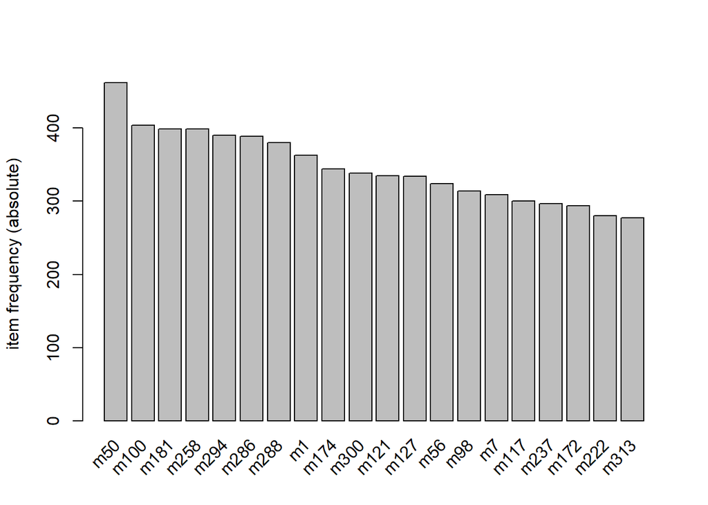

```r
itemFrequencyPlot(train_likes, 'absolute', topN = 20)
```

## Run apriori and extract lhs and rhs

##### Take custom support and confidence

Here we have taken support = .20 and Confidence = 0.70  
Here we have found *6771* rules which satisfy above conditions.

```r
rules <- apriori(train_likes, list(support = 0.20, confidence = 0.70, minlen = 2))
```

```
## Apriori
##
## Parameter specification:
##  confidence minval smax arem  aval originalSupport maxtime support minlen
##         0.7    0.1    1 none FALSE            TRUE       5     0.2      2
##  maxlen target   ext
##      10  rules FALSE
##
## Algorithmic control:
##  filter tree heap memopt load sort verbose
##     0.1 TRUE TRUE  FALSE TRUE    2    TRUE
##
## Absolute minimum support count: 150
##
## set item appearances ...[0 item(s)] done [0.00s].
## set transactions ...[1654 item(s), 754 transaction(s)] done [0.01s].
## sorting and recoding items ... [133 item(s)] done [0.00s].
## creating transaction tree ... done [0.00s].
## checking subsets of size 1 2 3 4 5 6 done [0.03s].
## writing ... [6771 rule(s)] done [0.00s].
## creating S4 object  ... done [0.00s].
```

```r
rules_lhs = lhs(rules)
rules_rhs = rhs(rules)
```

## Top 10 rules order by lift

```r
inspect(head(sort(rules, by = "lift"), 10))
```

```
##      lhs                     rhs    support   confidence lift     count
## [1]  {m174,m181,m183}     => {m176} 0.2082228 0.8674033  2.843574 157
## [2]  {m174,m181,m183,m50} => {m176} 0.2082228 0.8674033  2.843574 157
## [3]  {m174,m195,m79}      => {m96}  0.2029178 0.9000000  2.839331 153
## [4]  {m172,m174,m183,m50} => {m176} 0.2002653 0.8628571  2.828671 151
## [5]  {m172,m174,m183}     => {m176} 0.2055703 0.8611111  2.822947 155
## [6]  {m174,m176,m181,m50} => {m183} 0.2082228 0.8870056  2.821950 157
## [7]  {m172,m176,m50}      => {m183} 0.2068966 0.8863636  2.819908 156
## [8]  {m195,m50,m79}       => {m96}  0.2002653 0.8934911  2.818796 151
## [9]  {m172,m174,m176,m50} => {m183} 0.2002653 0.8830409  2.809337 151
## [10] {m195,m79}           => {m96}  0.2122016 0.8888889  2.804277 160
```

## Execute Rules on test data set

- It will find all the rules subset of basket
- Return all the predicted movies
- Perform match with original test dataset for correct prediction.
- Update the counter for correct and predict

```r
correct = 0
total = 0
for (i in 1:test_likes.count) {
    # for each transaction (user) 189 records in test.  find rules with subset
    # of Basket of test users covers using rule LHS.
    lhs_in_txn <- is.subset(rules_lhs, test_likes[i])
    # Find rules RHS where LHS is subset of Basket for user.
    true_rules_rhs <- as(rules_rhs[as.logical(lhs_in_txn)], "list")
    # Combine(Union) all the predicted RHS movie result and cast to Vector
    pred = Reduce(union, true_rules_rhs, vector("character"))
    # increment correct and total predictions Correct will increment for correct
    # match done between Prediction and test data
    correct = correct + sum(pred %in% test_likes.list[[i]])
    # Total will increment for all predictions made by our rules.
    total = total + length(pred)
}
```

## Find Precision using correct and Total

```r
precision = correct / total
```

## Display final result

```r
cat('No. of test users: ', test_likes.count, '\n')
```

```
## No. of test users:  189
```

```r
cat('Correct predictions: ', correct, '\n')
```

```
## Correct predictions:  2549
```

```r
cat('Total predictions: ', total, '\n')
```

```
## Total predictions:  4299
```

```r
cat('Precision: ', precision*100,'%', '\n')
```

```
## Precision:  59.29286 %
```

## SUMMARY

- Here we have performed Association analysis on simple data of users like movies.
- We have used subset method to find all the subset find of basket in Rules generated.
- Final Accuracy acquired is **~60%** , which seems good with very less information available.
- We will ocntinue the further analysis of data in following slides.